# Big Data Analysis R Assignment

Kopsco and Ada

4/3/2018

```r
knitr::opts_chunk$set(echo = FALSE)
```

The Portal, AZ rodent dataset provides information on all rodents sampled among 24 experimental plots in the Chihuahan Desert between 1977 and 2002. The following plot examines the total number of species over the entire observation time. While there is considerable change in total abundance among years, the most abundant species remained relatively stable. *C. baileyi* and *D. merriami* were the most abundant species present, however *C. baileyi* population exploded only in the late 1990s as *D. merriami*’s abundance began to decline.

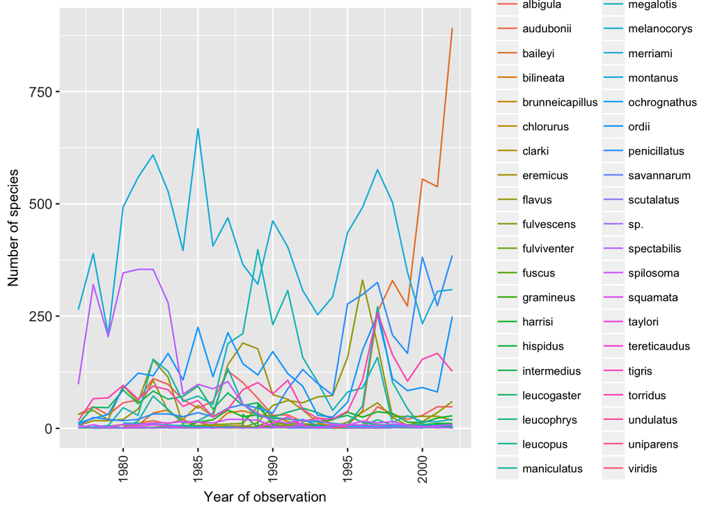

Overall, the average total number of species increased over the study period. The total average rodent population experienced a slow decline starting in the late 1980s, and then a sharp resurgence in the mid 1990s.

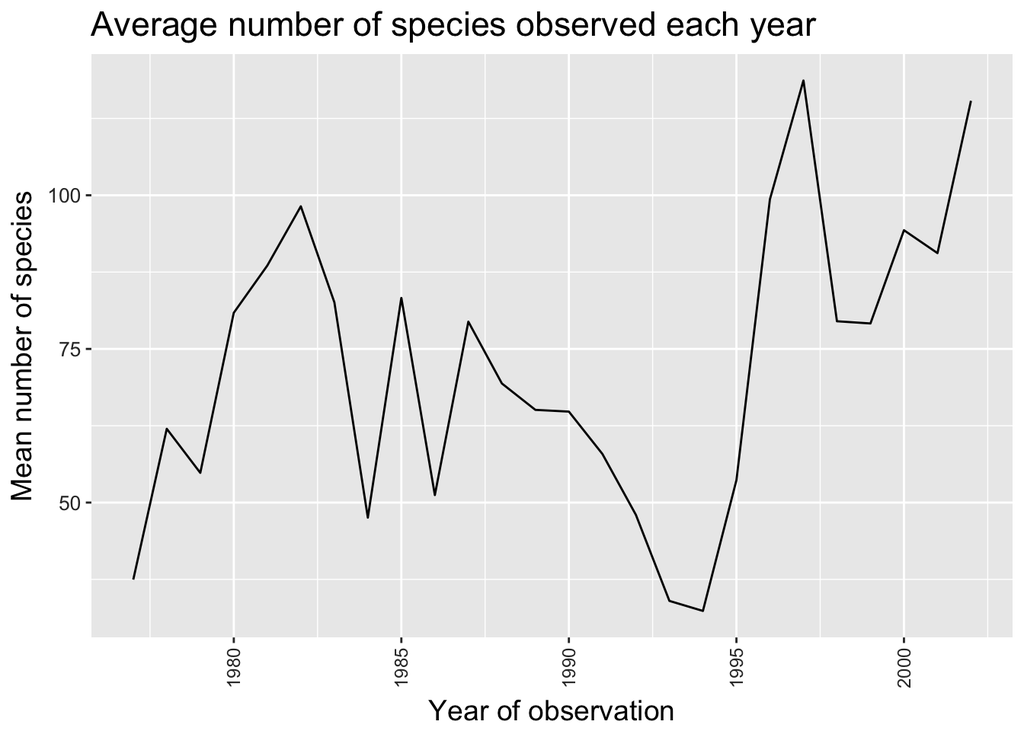

Most plots appear to contain fewer than 60 individuals of a particular species each year. However, *C. baileyi* and *D. merriami* exceed this threshold in several plots in various years. In particular, plot 4 had a surge of *D. merriami* in 1990, and *C. baileyi* increased in the late 1990s in plots 3, 6, 13, 18, 19, 20, 21, 22.

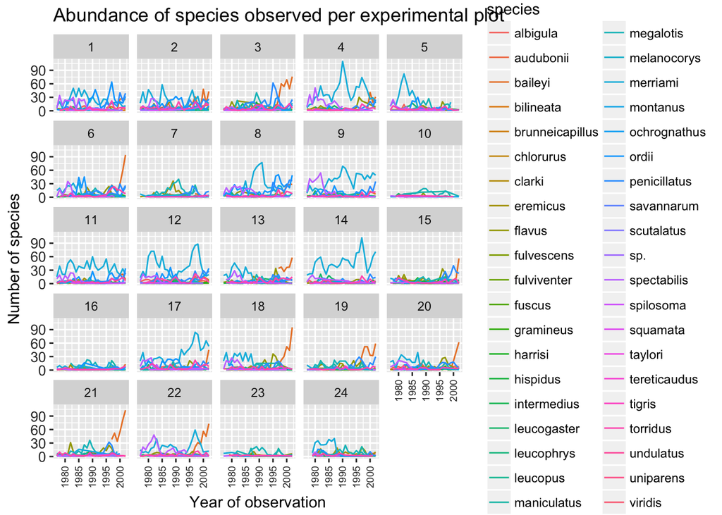

Plot 4 appears to host the largest abundance of species of all plots.

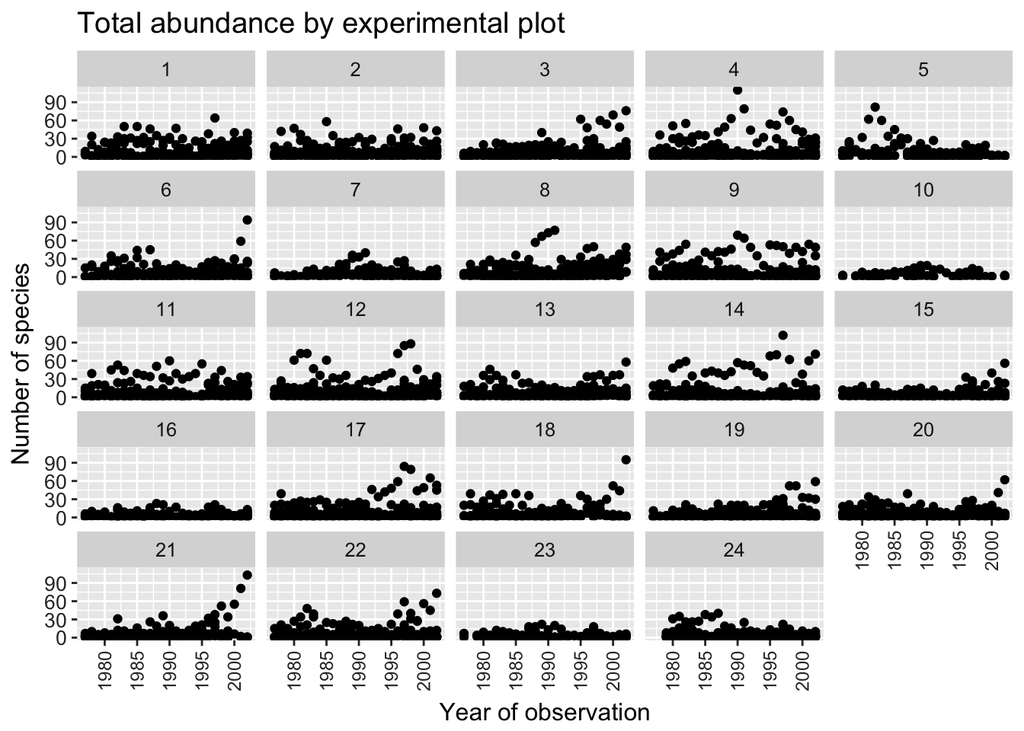

A boxplot of the mean abundance per experimental plot reveals a large number of outliers. A Kruskal-Wallis one way test of variance reveals that there is a significant difference among the mean species abundances per plot_id (p = 5.558716910^{-14}).

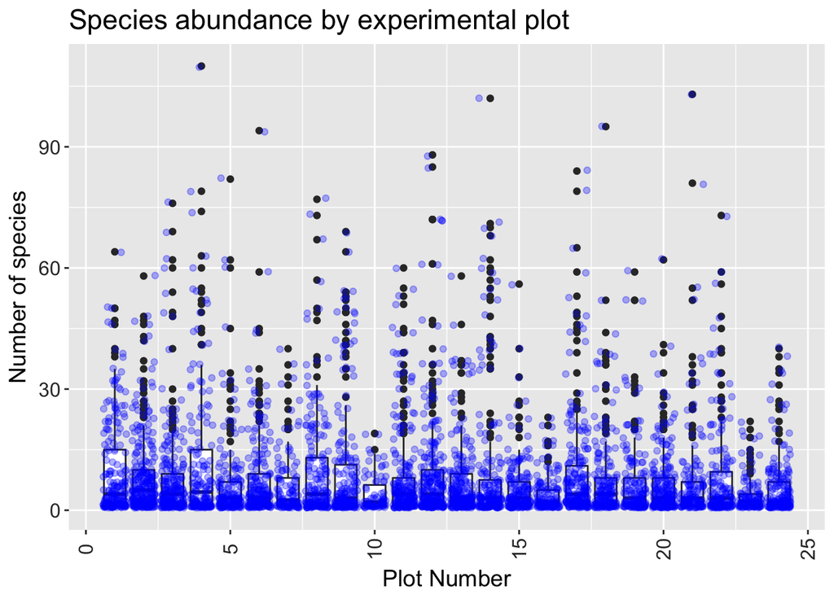

Of the top five most abundant species, *C. baileyi* and *D. merriami* are the most abundant for all experimental plots. However, there is a lot of variance in their sample numbers throughout the years.

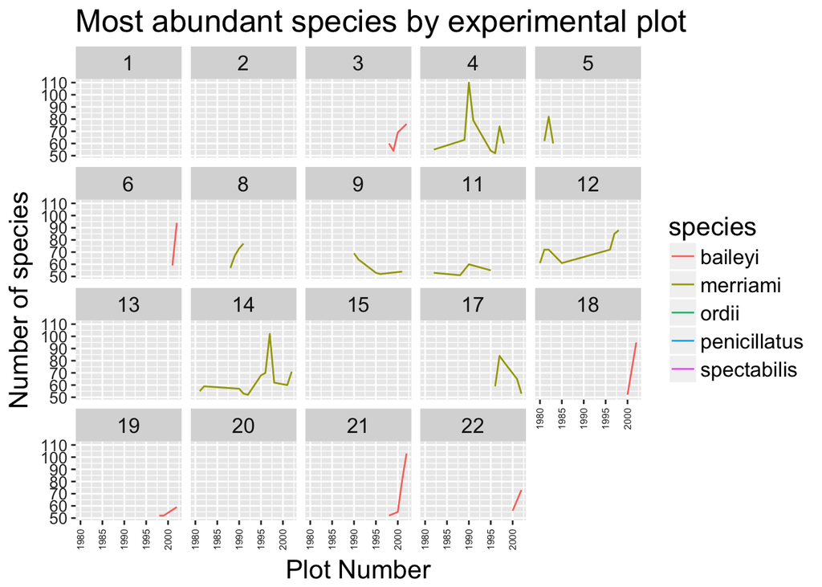

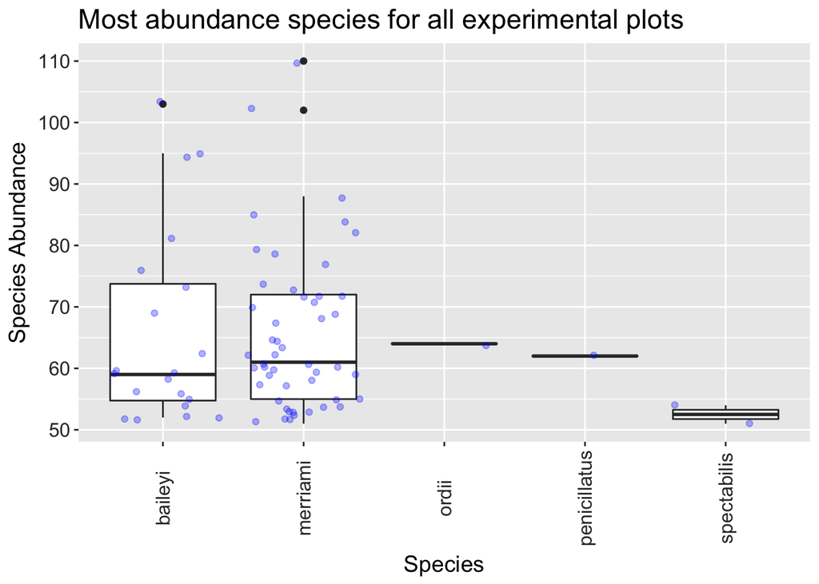

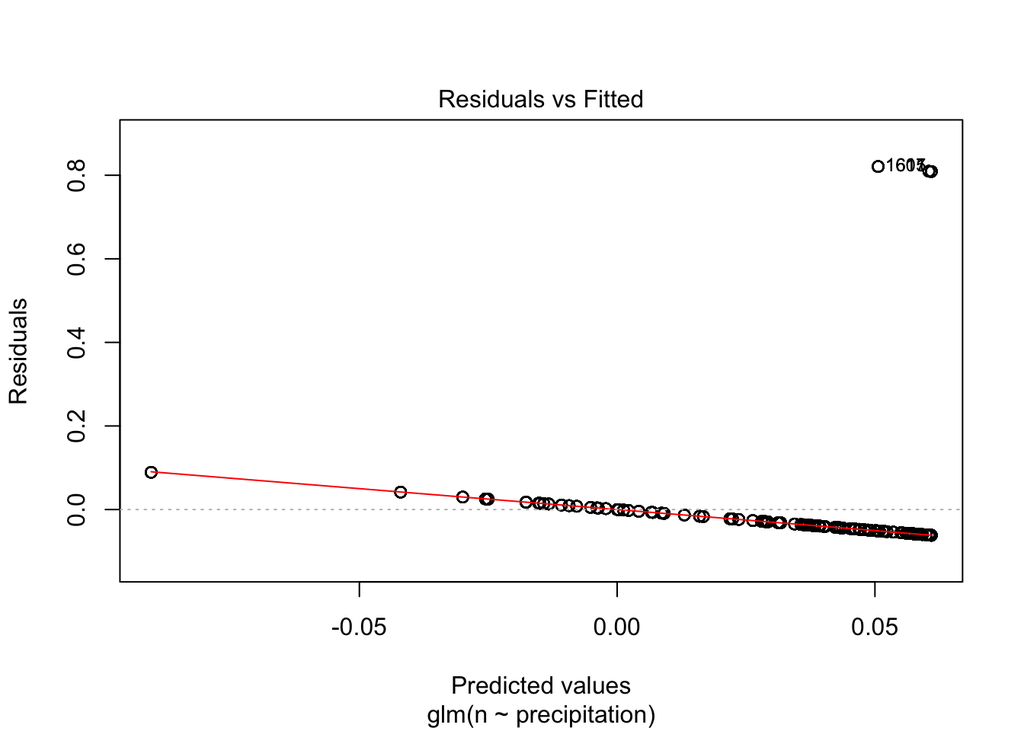

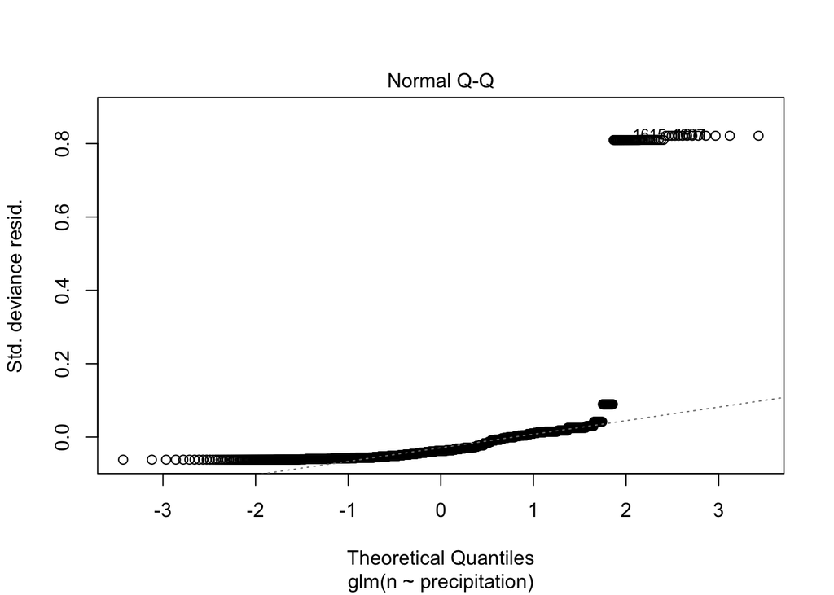

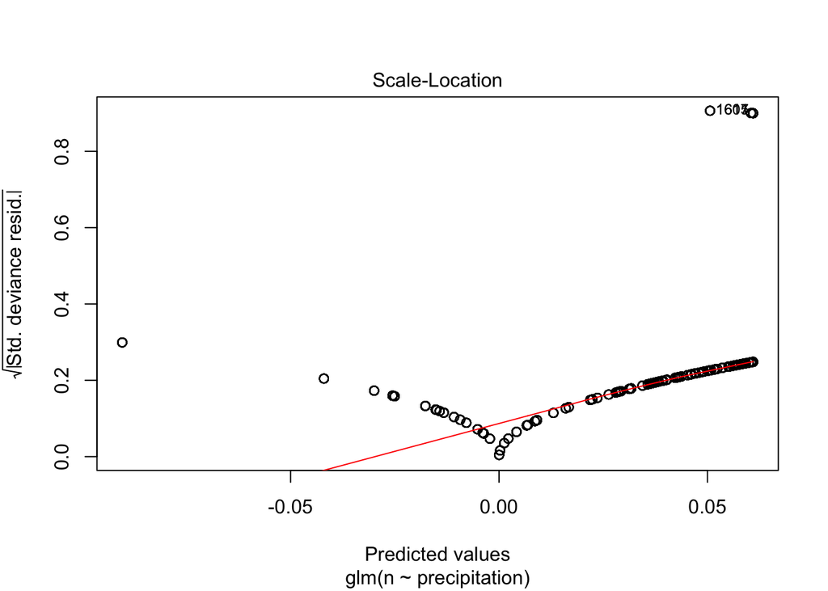

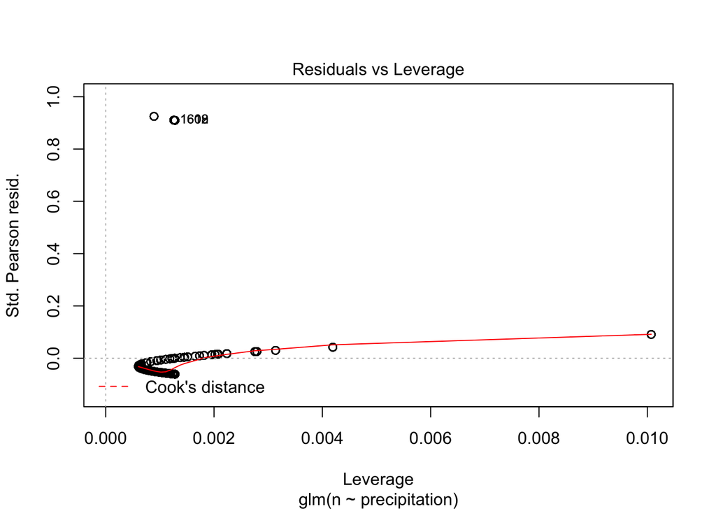

Using a Kruskal Wallace test to compare the amount of precipitation per year, there is no significant difference among sampling years (p = 0.9109054). This suggests that annual precipitation is not behind the difference in rodent population abundance.

```
##       Year      precipitation          n
##  Min.   :1980   Min.   :  0.00   Min.   :1.000
##  1st Qu.:1982   1st Qu.:  6.10   1st Qu.:1.000
##  Median :1984   Median : 22.61   Median :1.000
##  Mean   :1984   Mean   : 31.36   Mean   :1.036
##  3rd Qu.:1987   3rd Qu.: 53.84   3rd Qu.:1.000
##  Max.   :1989   Max.   :156.46   Max.   :2.000
```

Average weight per species:

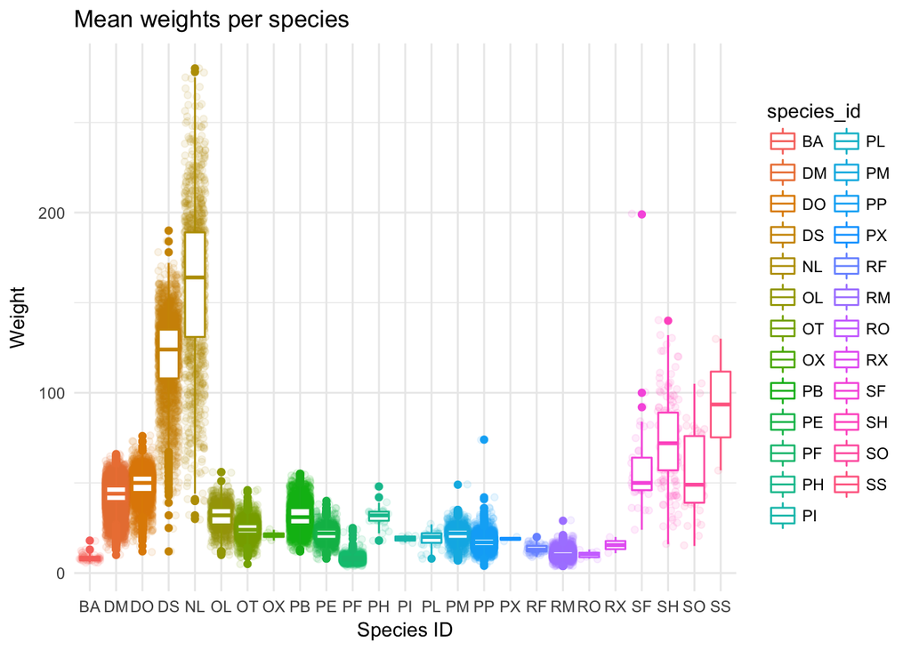

This box-plot illustrates mean weights for each species in the survey data.

Summary the mean weights per species:

```
## # A tibble: 25 x 2
##    species_id mean_weight
##    <chr>            <dbl>
##  1 BA                8.60
##  2 DM               43.2
##  3 DO               48.9
##  4 DS              120.
##  5 NL              159.
##  6 OL               31.6
##  7 OT               24.2
##  8 OX               21.0
##  9 PB               31.7
## 10 PE               21.6
## # ... with 15 more rows
```

We choose top five most abundant species and compare mean hindfoot length and weight.

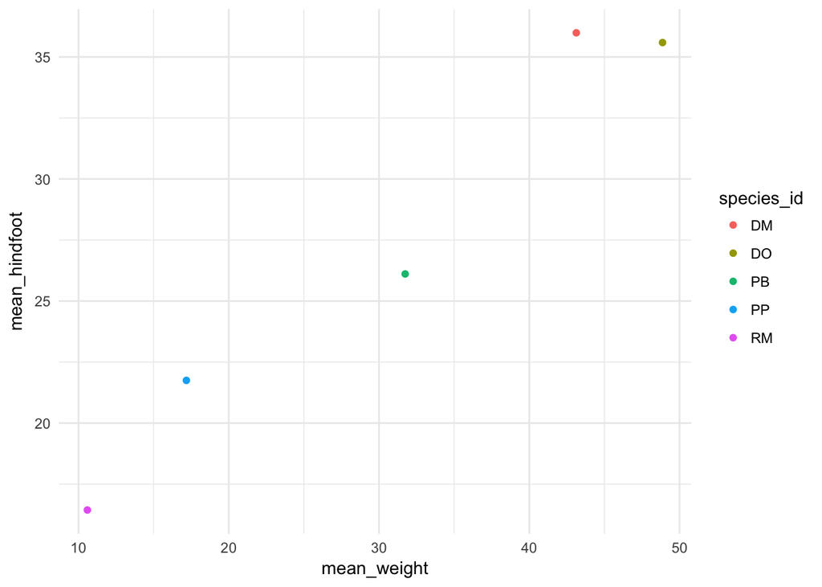

Summary of the relationship between species’ mean weight between mean hindfoot length:

```
##
## Call:
## glm(formula = mean_weight ~ mean_hindfoot, data = means_for_top_five)
##
## Deviance Residuals:
##      1       2       3       4       5
## -3.660   2.828   3.432  -2.971   0.372
##
## Coefficients:
##               Estimate Std. Error t value Pr(>|t|)
## (Intercept)   -20.5366     6.1693  -3.329  0.04476 *
## mean_hindfoot   1.8707     0.2185   8.563  0.00335 **
## ---
## Signif. codes:  0 '***' 0.001 '**' 0.01 '*' 0.05 '.' 0.1 ' ' 1
##
## (Dispersion parameter for gaussian family taken to be 14.04789)
##
##     Null deviance: 1072.146  on 4  degrees of freedom
## Residual deviance:   42.144  on 3  degrees of freedom
## AIC: 30.848
##
## Number of Fisher Scoring iterations: 2
```